# Practice data visualization with R((Survey LOL team in LMS))

SkySpiriT

2018年5月9日

## Data Visualization!

The mission this week is learning how to use ggplot to visualize data.

It’s a work which need many numeric data.

So i decide to research the player of LOL in LMS league!

```r
library(plotly)
library(RColorBrewer)
```

## What’s next?

I found the data from http://2017.lms.garena.tw/stats

After few second, i decided to find who is the best adc of LMS!

I think there is three important status of a great ADC: KDA ,Kill participatuon and minion gain per minion .

First things to do is that input the data in a dataframe!

```r
Data=data.frame(
names=factor(c('AN','BeBe','Breeze','CorGi','GodKwai','LBB','LilV','Rabi2','RD',
                 'BeBe','Breaker','Breeze','CorGi','Dee','NL','Raison','RD',
                 'AN','BeBe','Betty','Breeze','Dee','GodKwai','LBB','Unified','Wako',
                 'AN','BeBe','Betty','Breeze','Dee','Enzz','GodKwai','LBB','LilV','Ran','Unified')
             ,levels=c('AN','BeBe','Betty','Breaker','Breeze','CorGi','Dee','Enzz','GodKwai','LBB','LilV','NL','Rabi2','Ran','Raison','RD','Unified','Wako')),
KDA=factor(c(5.8,6.8,2.9,2.5,4.8,3.1,4.3,1.1,6.9,
               8.3,1.5,2.2,3.7,3.8,7.8,3.7,13.5,
               6.5,5.6,8.8,2.5,2.8,3.9,3.3,4.3,2.1,
               3.4,5,7.3,3.7,3.4,1.5,2.9,5,5.9,1.5,3.8)),
KP=factor(c(0.6810,0.7710,0.7550,0.7650,0.7290,0.6780,0.8950,0.6400,0.8140,
              0.7650,0.6000,0.6970,0.7550,0.8050,0.7590,0.7380,0.7110,
              0.6530,0.6880,0.6330,0.6820,0.6500,0.6590,0.7110,0.6610,0.6620,
              0.5630,0.6340,0.7010,0.6180,0.6820,0.5680,0.7220,0.5880,0.6940,0.4620,0.6950)),
mpm=factor(c(8.2,8.5,8.6,8.5,8.4,8.0,9.5,6.5,8.6,
               8.8,8.8,8.6,8.9,8.8,9.2,9.2,9.2,
               9.7,9.2,9.5,8.7,8.6,8.1,8.3,8.8,9.1,
               9.6,9.4,10.4,10,8.9,8.4,8.4,8.0,9.7,8.5,9.5)),
Pt=factor(c(930,994,144,776,994,995,73,796,110,
            1041,32,977,1055,1040,1009,1056,74,
            1061,1181,1036,1130,1161,1075,790,1152,976,
            964,1114,956,1209,1184,413,669,67,1181,52,1232)),
time=factor(c('2016spring','2016spring','2016spring','2016spring','2016spring','2016spring','2016spring','2016spring','2016spring',
              '2016summer','2016summer','2016summer','2016summer','2016summer','2016summer','2016summer','2016summer',
              '2017spring','2017spring','2017spring','2017spring','2017spring','2017spring','2017spring','2017spring','2017spring',
              '2017summer','2017summer','2017summer','2017summer','2017summer','2017summer','2017summer','2017summer','2017summer','2017summer','2017summer')
            ,levels=c('2016spring','2016summer','2017spring','2017summer')))
```

## Let’s take a look!

let’s see the data between palyers.

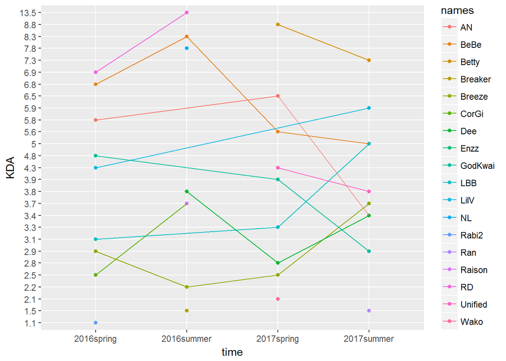

```r
ggplot(data=Data, aes(x=time, y=KDA, group=names, colour=names)) + geom_point() +geom_line()
```

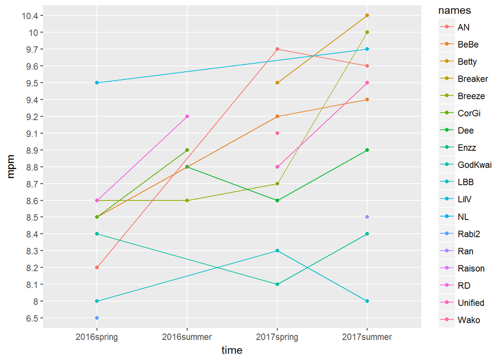

```r
ggplot(data=Data, aes(x=time, y=mpm, group=names, colour=names)) + geom_point() +geom_line()
```

In minion gain per minion.I find that Betty,LilV,RD,BeBe,Unified, have better performence than others.

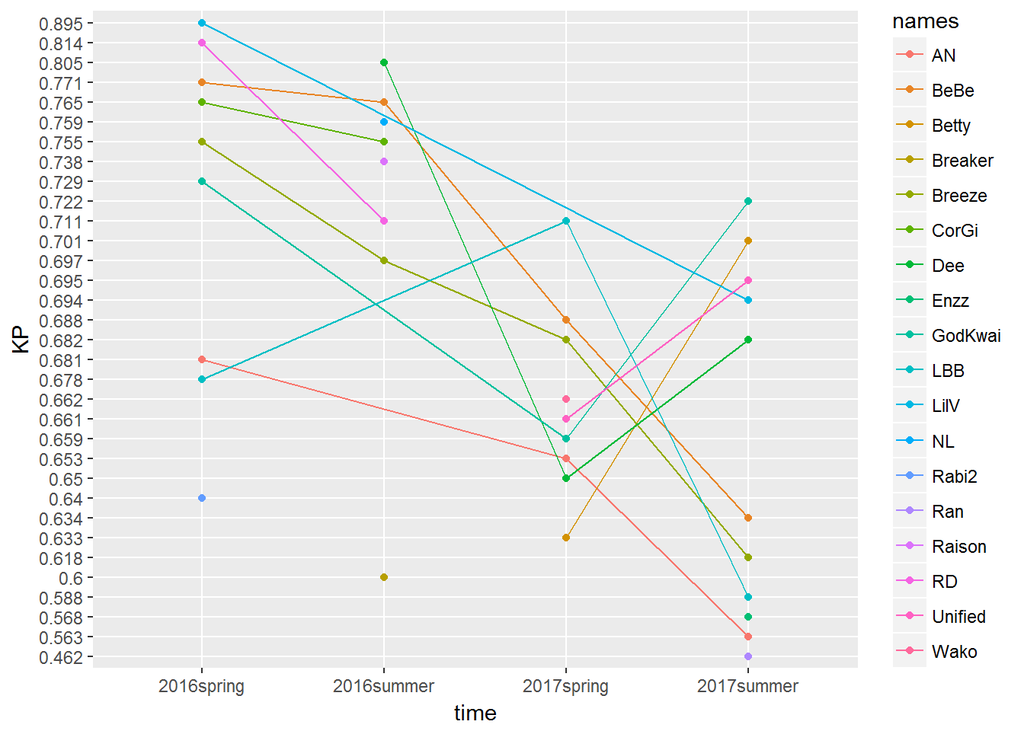

```r
ggplot(data=Data, aes(x=time, y=KP, group=names, colour=names)) + geom_point() +geom_line()
```

In kill participation.I find that LilV,RD,Unified,Corgi,BeBe have better performence than others.

## First Console

Because the research , i think that:

The best ADC player is Lilv!

2nd is unified !

3rd is betty!

But the data only have 2 years,and many player didn’t play game in each season.

So the research isn’t absolutly.

## Another research & second Console

let’s take a look how many time player had player!

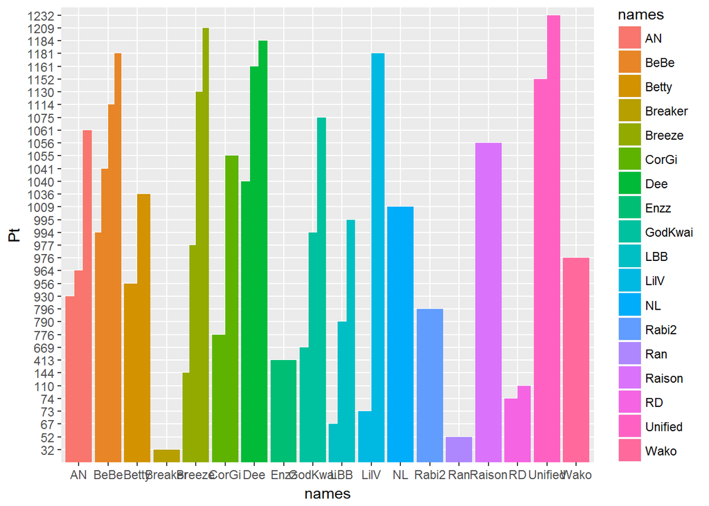

```r
ggplot(data=Data, aes(x=names, y=Pt, fill=names)) +  geom_bar(stat="identity", position=position_dodge())
```

we can find that there is a trend that the stronger player play more time.

Except three player.

Lilv & Dee & Raison

Lilv as a ADC in TPA,he didn’t have many chance to play because there is a ex-champion ADC in their team:BeBe.

He can’t use his power on the race too much .It have a litte bit pity .

Dee & Raison is the ADC of M17 & HKE.But their performance wasn’t as goog as others.But their playing time is as much as other good players.

It mean the stratege of the team isn’t good or the teams needed more powerful player as their ADC.